```python
from IPython.display import HTML
```

```python
HTML('''<script>
code_show=true;
function code_toggle() {
 if (code_show){
 $('div.input').hide();
 } else {
 $('div.input').show();
 }
 code_show = !code_show
}
$( document ).ready(code_toggle);
</script>
The raw code for this IPython notebook is by default hidden for easier reading.
To toggle on/off the raw code, click <a href="javascript:code_toggle()">here</a>.''')
```

The raw code for this IPython notebook is by default hidden for easier reading. To toggle on/off the raw code, click here.

# Introduction

**TeleMarketing** was introduced in 1970s as a method of direct marketing. Telemarketing is a method where leads are generated through telephone calls or Face to Face Web-Conference. Charitable organizations, alumni associations, and political parties often use telemarketing to solicit donations. Marketing research companies use telemarketing techniques to survey the prospective or past customers of a client’s business in order to assess market acceptance of or satisfaction with a particular product, service, brand, or company. Public opinion polls are conducted in a similar manner.

This project will deal with a database that provides information which can help in analysing whether the caller will be a potential buyer or not. The Database contains the variables as of a Portuguese bank that wants to sell 'Term Loans' to it's potential callers.

The Variables contained in the database are listed as follows:

age - Age of the client- (numeric)

job - Client’s occupation - (categorical) (admin, bluecollar, entrepreneur, housemaid, management, retired, selfemployed, services, student, technician, unemployed, unknown)

marital - Client’s marital status - (categorical) (divorced, married, single, unknown, note: divorced means divorced or widowed)

education - Client’s education level - (categorical) (basic.4y, basic.6y, basic.9y, high.school, illiterate, professional.course, university.degree, unknown)

default - Indicates if the client has credit in default - (categorical) (no, yes, unknown)

housing - Does the client has a housing loan? - (categorical) (no, yes, unknown)

loan - Does the client has a personal loan? - (categorical) (no, yes, unknown’)

contact - Type of communication contact - (categorical) (cellular, telephone)

month - Month of last contact with client - (categorical) (January - December)

day_of_week - Day of last contact with client - (categorical) (Monday - Friday)

duration - Duration of last contact with client, in seconds - (numeric) For benchmark purposes only, and not reliable for predictive modeling

campaign - Number of client contacts during this campaign - (numeric) (includes last contact)

pdays - Number of days from last contacted from a previous campaign - (numeric) (999 means client was not previously contacted)

previous - Number of client contacts performed before this campaign - (numeric)

poutcome - Previous marketing campaign outcome - (categorical) (failure, nonexistent , success)

emp.var.rate - Quarterly employment variation rate - (numeric)

cons.price.idx - Monthly consumer price index - (numeric)

cons.conf.idx - Monthly consumer confidence index - (numeric)

euribor3m - Daily euribor 3 month rate - (numeric)

nr.employed - Quarterly number of employees - (numeric)

Output variable (desired target) - Term Deposit - subscription verified (binary: ‘yes’,‘no’)

# Data Analysis & Findings

**1.Import the necessary libraries in Python.**

```python
import numpy as np
import pandas as pd
import matplotlib.pyplot as plt
import seaborn as sns
%matplotlib inline
```

**The First Four values of the Data Frame**

```python
data = pd.read_csv('train.csv',sep=';')
```

```python
data.head(4)
```

|  | age | job | marital | education | default | housing | loan | contact | month | day_of_week | ... | campaign | pdays | previous | poutcome | emp.var.rate | cons.price.idx | cons.conf.idx | euribor3m | nr.employed | y |
| --- | --- | --- | --- | --- | --- | --- | --- | --- | --- | --- | --- | --- | --- | --- | --- | --- | --- | --- | --- | --- | --- |
| 0 | 30 | blue-collar | married | basic.9y | no | yes | no | cellular | may | fri | ... | 2 | 999 | 0 | nonexistent | -1.8 | 92.893 | -46.2 | 1.313 | 5099.1 | no |
| 1 | 39 | services | single | high.school | no | no | no | telephone | may | fri | ... | 4 | 999 | 0 | nonexistent | 1.1 | 93.994 | -36.4 | 4.855 | 5191.0 | no |
| 2 | 25 | services | married | high.school | no | yes | no | telephone | jun | wed | ... | 1 | 999 | 0 | nonexistent | 1.4 | 94.465 | -41.8 | 4.962 | 5228.1 | no |
| 3 | 38 | services | married | basic.9y | no | unknown | unknown | telephone | jun | fri | ... | 3 | 999 | 0 | nonexistent | 1.4 | 94.465 | -41.8 | 4.959 | 5228.1 | no |

4 rows × 21 columns

**Some Technical Information about the Data Frame**

```python
data.info()
```

```
<class 'pandas.core.frame.DataFrame'>
RangeIndex: 2999 entries, 0 to 2998
Data columns (total 21 columns):
age               2999 non-null int64
job               2999 non-null object
marital           2999 non-null object
education         2999 non-null object
default           2999 non-null object
housing           2999 non-null object
loan              2999 non-null object
contact           2999 non-null object
month             2999 non-null object
day_of_week       2999 non-null object
duration          2999 non-null int64
campaign          2999 non-null int64
pdays             2999 non-null int64
previous          2999 non-null int64
poutcome          2999 non-null object
emp.var.rate      2999 non-null float64
cons.price.idx    2999 non-null float64
cons.conf.idx     2999 non-null float64
euribor3m         2999 non-null float64
nr.employed       2999 non-null float64
y                 2999 non-null object
dtypes: float64(5), int64(5), object(11)
memory usage: 492.1+ KB
```

There are 11 categorical variables and 10 continuous variables.

**Quantitative Summary**

```python
data.describe().T
```

|  | count | mean | std | min | 25% | 50% | 75% | max |
| --- | --- | --- | --- | --- | --- | --- | --- | --- |
| age | 2999.0 | 39.889296 | 10.282229 | 18.000 | 32.000 | 38.000 | 47.000 | 88.000 |
| duration | 2999.0 | 255.085028 | 256.265737 | 0.000 | 101.000 | 180.000 | 316.000 | 3643.000 |
| campaign | 2999.0 | 2.526842 | 2.556995 | 1.000 | 1.000 | 2.000 | 3.000 | 35.000 |
| pdays | 2999.0 | 962.227743 | 187.599866 | 0.000 | 999.000 | 999.000 | 999.000 | 999.000 |
| previous | 2999.0 | 0.192064 | 0.551960 | 0.000 | 0.000 | 0.000 | 0.000 | 6.000 |
| emp.var.rate | 2999.0 | 0.079093 | 1.559126 | -3.400 | -1.800 | 1.100 | 1.400 | 1.400 |
| cons.price.idx | 2999.0 | 93.584553 | 0.581162 | 92.201 | 93.075 | 93.876 | 93.994 | 94.767 |
| cons.conf.idx | 2999.0 | -40.578226 | 4.594237 | -50.800 | -42.700 | -41.800 | -36.400 | -26.900 |
| euribor3m | 2999.0 | 3.605769 | 1.739625 | 0.635 | 1.334 | 4.857 | 4.961 | 5.045 |
| nr.employed | 2999.0 | 5165.642314 | 74.384632 | 4963.600 | 5099.100 | 5191.000 | 5228.100 | 5228.100 |

### Y - Will take the term loan or not!

This variable tells whether the call led to a successful subscription of Term Deposit or not.

```python
data_no = data[data['y']=='no']
data_yes = data[data['y']=='yes']
```

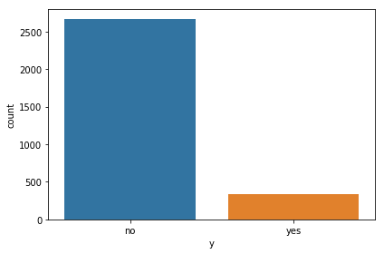

```python
sns.countplot(data['y'])
plt.tight_layout()
plt.show()
```

```python
print('VALUES IN PERCENTAGE')
print(data[data['y']=='yes']['y'].value_counts()/len(data['y'])*100)
print(data[data['y']=='no']['y'].value_counts()/len(data['y'])*100)
```

```
VALUES IN PERCENTAGE
yes    11.037012
Name: y, dtype: float64
no    88.962988
Name: y, dtype: float64
```

# Short Summary

```python
def Graph_Summary(input_value):
    if((type(data[input_value].iloc[0]) == np.int64) | (type(data[input_value].iloc[0]) == np.float64) ) :

        f = plt.figure(figsize=(15,15))
        f.set_figheight(8)
        f.set_figwidth(25)

        plt.subplot(131)
        sns.set()
        plt.hist(data[input_value],bins = 50)
        plt.xlabel(input_value)
        plt.ylabel('F(X)')



        plt.subplot(132)
        sns.set()
        X = np.sort(data[input_value])
        Y = np.arange(1,len(X)+1)/len(X)
        plt.plot(X,Y,marker='.',linestyle='none')
        plt.xlabel(input_value)
        plt.ylabel('ECDF')



        plt.subplot(133)
        sns.set()
        plt.boxplot(data[input_value])
        plt.xlabel(input_value)

        plt.show()
    else: return None
```

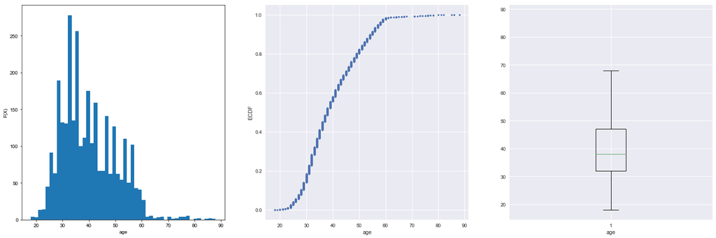

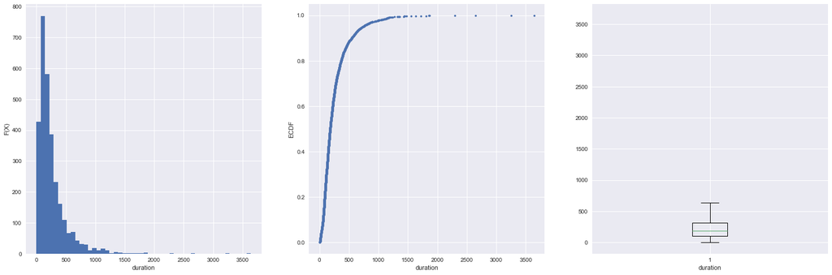

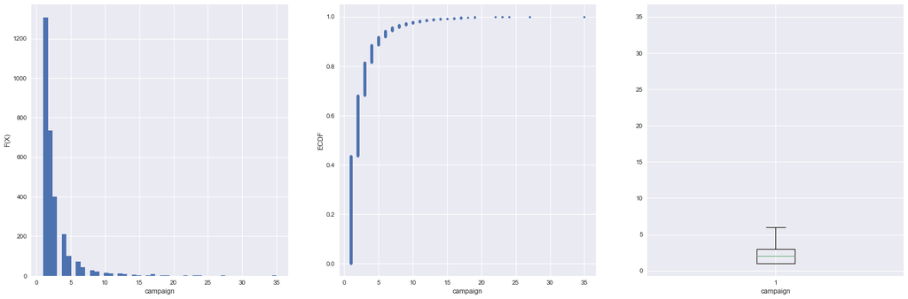

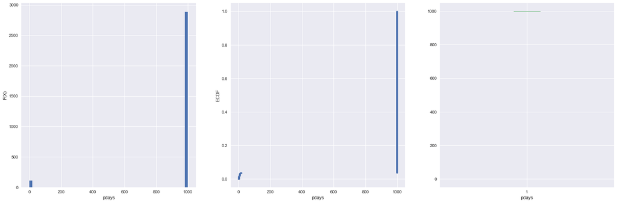

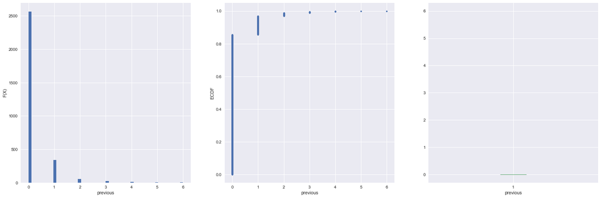

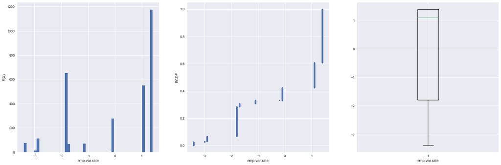

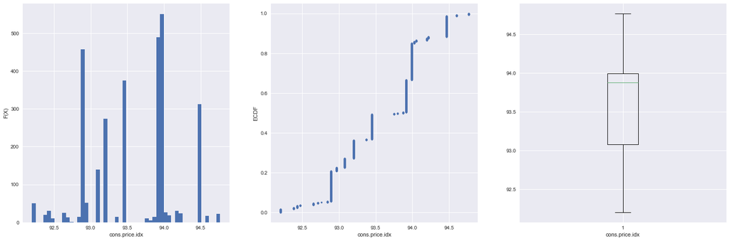

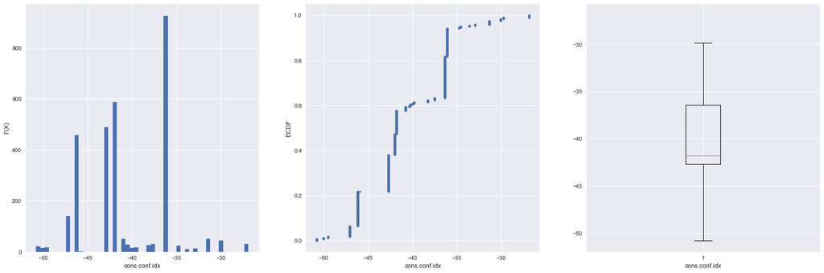

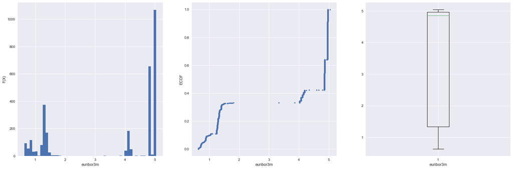

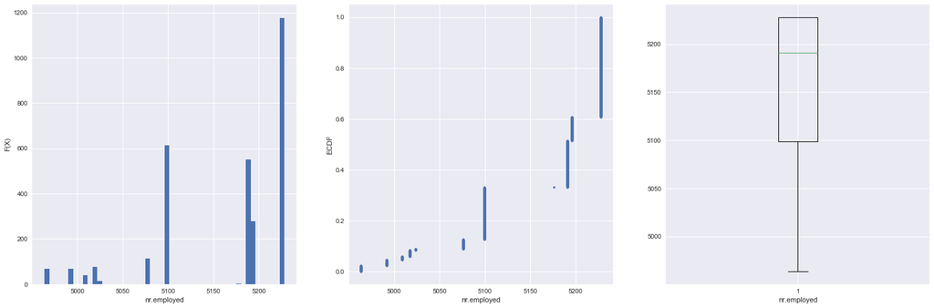

```python
for i in data.columns:
    Graph_Summary(i)
```

The above graphs shows the statistical summary of continuous variables.

```python
def Cat_Summary(input_value):

    if((type(data[input_value].iloc[0]) != np.int64) | (type(data[input_value].iloc[0]) != np.float64) ) :
        if(data[input_value].nunique() < 10 ):
            print(input_value)
            print('Number of Uniques: ',data[input_value].nunique(),'   ','Unique Values: ',data[input_value].unique())
            print('------------------------------------------------------------------------------------------------------')
        else: return None

    else: return None
```

```python
print('Categorical Unique Values:')
for i in data.columns:
    Cat_Summary(i)
```

```
Categorical Unique Values:
marital
Number of Uniques:  4     Unique Values:  ['married' 'single' 'divorced' 'unknown']
------------------------------------------------------------------------------------------------------
education
Number of Uniques:  7     Unique Values:  ['basic.9y' 'high.school' 'university.degree' 'professional.course'
 'basic.6y' 'basic.4y' 'unknown']
------------------------------------------------------------------------------------------------------
default
Number of Uniques:  2     Unique Values:  ['no' 'unknown']
------------------------------------------------------------------------------------------------------
housing
Number of Uniques:  3     Unique Values:  ['yes' 'no' 'unknown']
------------------------------------------------------------------------------------------------------
loan
Number of Uniques:  3     Unique Values:  ['no' 'unknown' 'yes']
------------------------------------------------------------------------------------------------------
contact
Number of Uniques:  2     Unique Values:  ['cellular' 'telephone']
------------------------------------------------------------------------------------------------------
day_of_week
Number of Uniques:  5     Unique Values:  ['fri' 'wed' 'mon' 'thu' 'tue']
------------------------------------------------------------------------------------------------------
previous
Number of Uniques:  7     Unique Values:  [0 2 1 3 5 4 6]
------------------------------------------------------------------------------------------------------
poutcome
Number of Uniques:  3     Unique Values:  ['nonexistent' 'failure' 'success']
------------------------------------------------------------------------------------------------------
y
Number of Uniques:  2     Unique Values:  ['no' 'yes']
------------------------------------------------------------------------------------------------------
```

### Conclusion

From the graphical summary of the **continuous varaibles**, it was observed that there existed a difference in mean and median, although the boxplot does not show any outliers, but this difference tells us that outliers are existing in these variables. Outliers, here, would be capped or floored rather than removed.

From the **categorical summary** it was observed that there existed some unknown categories. Such are to be treated as NAs and removed from the dataset.

# Capping Outliers

### Duration

```
Text(0.5,0,'Box Plot Of Duration Variable')
```

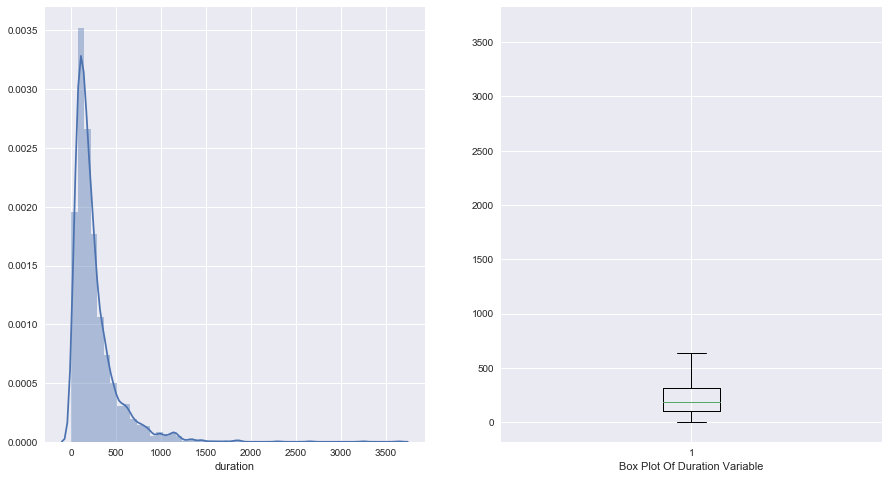

```python
f = plt.figure(figsize = (15,8))
f.set_figheight(8)
f.set_figwidth(15)

plt.subplot(121)
sns.distplot(data['duration'])
plt.subplot(122)
plt.boxplot(data['duration'])
plt.xlabel('Box Plot Of Duration Variable')
```

```
Text(0.5,0,'Duration for Calls Which sold Term Loans')
```

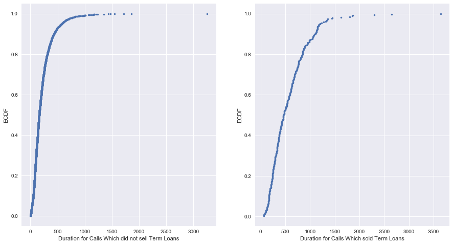

```python
f = plt.figure(figsize = (15,8))
f.set_figheight(8)
f.set_figwidth(15)

plt.subplot(121)
sns.set()
X = np.sort(data_no['duration'])
Y = np.arange(1,len(X)+1)/len(X)
plt.plot(X,Y,marker='.',linestyle='none')
plt.ylabel('ECDF')
plt.xlabel('Duration for Calls Which did not sell Term Loans')
plt.subplot(122)
sns.set()
X = np.sort(data_yes['duration'])
Y = np.arange(1,len(X)+1)/len(X)
plt.plot(X,Y,marker='.',linestyle='none')
plt.ylabel('ECDF')
plt.xlabel('Duration for Calls Which sold Term Loans')
```

```python
def cap_outs(values):
    for i in range(0,len(data)-1):
        if(values > 1500):
            values = 1500
        else: return values
    return values
```

```python
data['duration']=data['duration'].apply(cap_outs)
```

### PDAYS

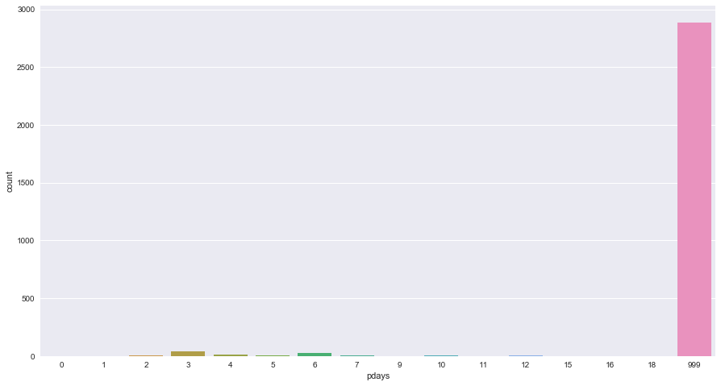

```python
plt.figure(figsize = (15,8))
sns.countplot(data['pdays'])
```

```python
def cap_outs(values):
    for i in range(0,len(data)-1):
        if(values > 900):
            values = 0
        else: return values
    return values

data['pdays']=data['pdays'].apply(cap_outs)
```

# Filtering Out the Unknown Values

```python
print('Categorical Unique Values:')
for i in data.columns:
    Cat_Summary(i)
```

```
Categorical Unique Values:
marital
Number of Uniques:  4     Unique Values:  ['married' 'single' 'divorced' 'unknown']
------------------------------------------------------------------------------------------------------
education
Number of Uniques:  7     Unique Values:  ['basic.9y' 'high.school' 'university.degree' 'professional.course'
 'basic.6y' 'basic.4y' 'unknown']
------------------------------------------------------------------------------------------------------
default
Number of Uniques:  2     Unique Values:  ['no' 'unknown']
------------------------------------------------------------------------------------------------------
housing
Number of Uniques:  3     Unique Values:  ['yes' 'no' 'unknown']
------------------------------------------------------------------------------------------------------
loan
Number of Uniques:  3     Unique Values:  ['no' 'unknown' 'yes']
------------------------------------------------------------------------------------------------------
contact
Number of Uniques:  2     Unique Values:  ['cellular' 'telephone']
------------------------------------------------------------------------------------------------------
day_of_week
Number of Uniques:  5     Unique Values:  ['fri' 'wed' 'mon' 'thu' 'tue']
------------------------------------------------------------------------------------------------------
previous
Number of Uniques:  7     Unique Values:  [0 2 1 3 5 4 6]
------------------------------------------------------------------------------------------------------
poutcome
Number of Uniques:  3     Unique Values:  ['nonexistent' 'failure' 'success']
------------------------------------------------------------------------------------------------------
y
Number of Uniques:  2     Unique Values:  ['no' 'yes']
------------------------------------------------------------------------------------------------------
```

```python
for i in range(0,len(data.columns)-1):
    for j in range(0,len(data)-1):
        if(data.iloc[j,i] == 'unknown'):
            data.iloc[j,i] = None
        else: None
```

```python
data.isna().sum()
```

```
age                 0
job                32
marital             9
education         138
default           596
housing            77
loan               77
contact             0
month               0
day_of_week         0
duration            0
campaign            0
pdays               0
previous            0
poutcome            0
emp.var.rate        0
cons.price.idx      0
cons.conf.idx       0
euribor3m           0
nr.employed         0
y                   0
dtype: int64
```

```python
len(data)
```

```
2999
```

```python
data = data.dropna()
```

```python
data.isna().sum()
```

```
age               0
job               0
marital           0
education         0
default           0
housing           0
loan              0
contact           0
month             0
day_of_week       0
duration          0
campaign          0
pdays             0
previous          0
poutcome          0
emp.var.rate      0
cons.price.idx    0
cons.conf.idx     0
euribor3m         0
nr.employed       0
y                 0
dtype: int64
```

```python
len(data)
```

```
2226
```

## Exploratory Data Analysis

**Figure 1:**

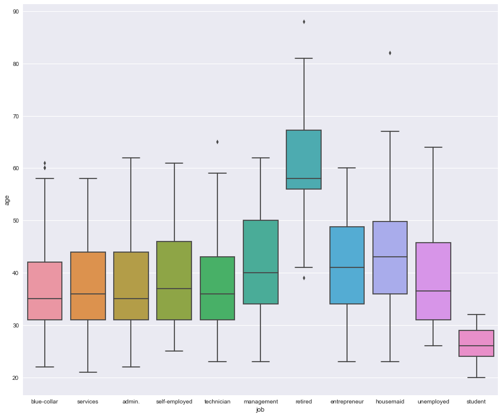

```python
plt.figure(figsize=(12,10))
sns.boxplot(y=data['age'],x=data['job'])
plt.tight_layout()
plt.show()
```

**In Figure 1:**

**This Box Plot shows the median ages for different Job status and the median age for each job status is given below:**

```python
data.groupby('job')['age'].median()
```

```
job
admin.           35.0
blue-collar      35.0
entrepreneur     41.0
housemaid        43.0
management       40.0
retired          58.0
self-employed    37.0
services         36.0
student          26.0
technician       36.0
unemployed       36.5
Name: age, dtype: float64
```

**Figure 2**

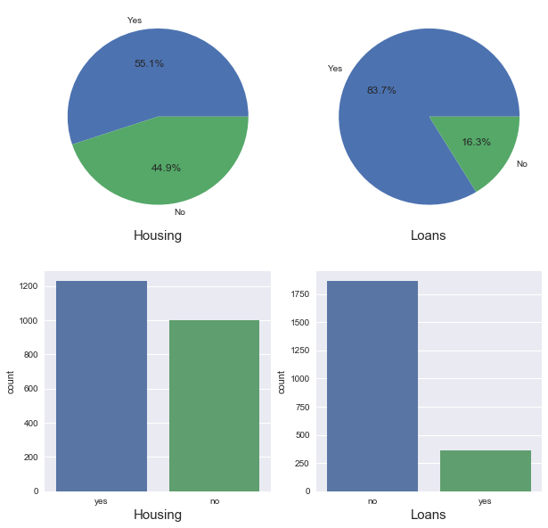

```python
import matplotlib
f = plt.figure(figsize=(8,8))
f.set_figheight(10)
f.set_figwidth(10)

plt.subplot(221)
plt.pie(list(data['housing'].value_counts()),labels=['Yes','No'],autopct='%1.1f%%',)
plt.xlabel('Housing',{'fontsize':15})

plt.subplot(222)
plt.pie(list(data['loan'].value_counts()),labels=['Yes','No'],autopct='%1.1f%%')
plt.xlabel('Loans',{'fontsize':15})

plt.subplot(223)
sns.countplot(data['housing'])
plt.xlabel('Housing',{'fontsize':15})

plt.subplot(224)
sns.countplot(data['loan'])
plt.xlabel('Loans',{'fontsize':15})
matplotlib.rcParams.update({'font.size': 15})
```

**In Figure 2**,

**Pie Chart Shows that:**

1)Out of the total, **55.1%** has housing loans and **44.9%** do not have a Housing Loan.

**The Count Plot shows that:**

1) 1227 of them has house loan and 999 of them do not have house loan.

**Figure 3**

```
Text(0.5,0,'poutcome')
```

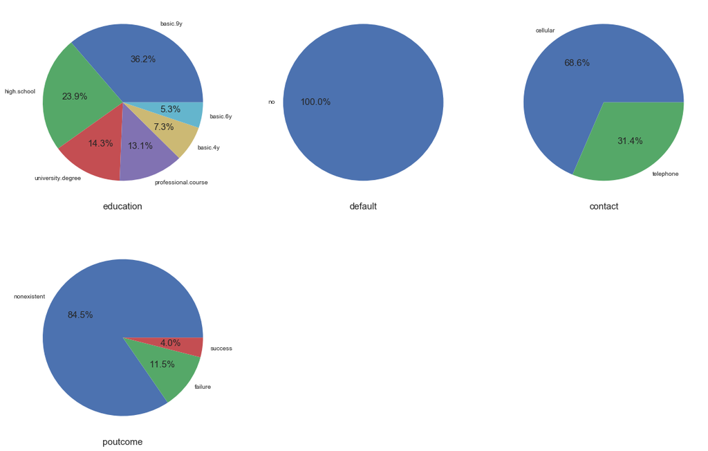

```python
f = plt.figure(figsize=(8,8))
f.set_figheight(13)
f.set_figwidth(20)

plt.subplot(231)
plt.pie(list(data['education'].value_counts()),labels=data['education'].unique(),autopct='%1.1f%%',)
plt.xlabel('education',{'fontsize':15})

plt.subplot(232)
plt.pie(list(data['default'].value_counts()),labels=data['default'].unique(),autopct='%1.1f%%')
plt.xlabel('default',{'fontsize':15})

plt.subplot(233)
plt.pie(list(data['contact'].value_counts()),labels=data['contact'].unique(),autopct='%1.1f%%')
plt.xlabel('contact',{'fontsize':15})

plt.subplot(234)
plt.pie(list(data['poutcome'].value_counts()),labels=data['poutcome'].unique(),autopct='%1.1f%%')
plt.xlabel('poutcome',{'fontsize':15})
```

**In Figure 3:**

**The Pie Chart Shows:**

2) Percentage of default shows that all those who have been contacted did not have a defaulting history or did not default in paying back of any loans.

3) Percentage of Contact, which shows 68.6% of the customers has a cell phone while the rest 31.4% has a telephone.

4) Percentage of POutcome, which shows that in the previous campaign, there was 4% success for buying a term loan, 11.5% failure and 84.5% non-existent(Maybe they said they would think about it and was never contacted again).

**Out of calls that were success in the previous campaign, how many of them took the term loan in this campaign?**

```python
success = data[data['poutcome']=='success']
```

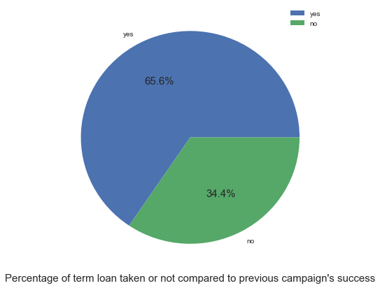

```python
plt.figure(figsize = (7,7))
plt.pie(list(success['y'].value_counts()),labels=success['y'].unique(),autopct='%1.1f%%')
plt.xlabel("Percentage of term loan taken or not compared to previous campaign's success",{'fontsize':15})
plt.legend()
```

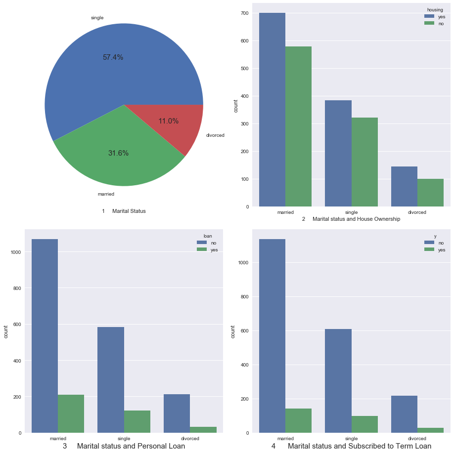

```python
import matplotlib
f = plt.figure(figsize=(8,8))
f.set_figheight(13)
f.set_figwidth(13)

plt.subplot(221)
plt.pie(list(data['marital'].value_counts()),labels=['single', 'married', 'divorced'],autopct='%1.1f%%')
plt.xlabel('1     Marital Status')

plt.subplot(222)
sns.countplot(data['marital'],hue=data['housing'])
plt.xlabel('2     Marital status and House Ownership')

plt.subplot(223)
sns.countplot(data['marital'],hue=data['loan'])
plt.xlabel('3     Marital status and Personal Loan',{'fontsize':15})

plt.subplot(224)
sns.countplot(data['marital'],hue=data['y'])
plt.xlabel('4      Marital status and Subscribed to Term Loan',{'fontsize':15})

plt.tight_layout()
```

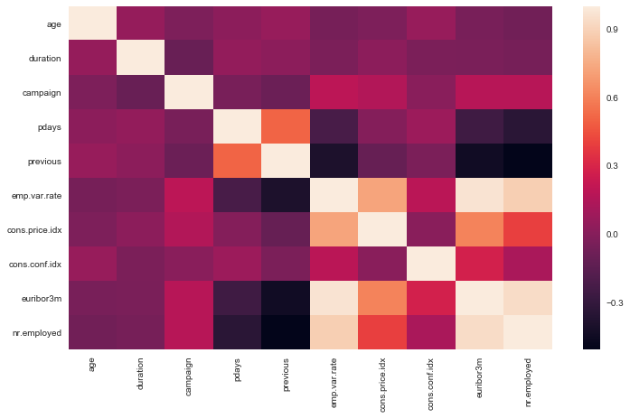

```python
plt.figure(figsize = (12,7))
sns.heatmap(data.corr())
```

**Monthly Trends of Continuous Variables**

```python
month  = {'apr':4,'aug':8,'dec':12,'jul':7,'jun':6,'mar':3,'may':5,'nov':11,'oct':10,'sep':9}
data['month'] = data['month'].map(month)
```

```python
by_month = data.groupby('month').sum()
```

```
Text(0.5,0,'previous')
```

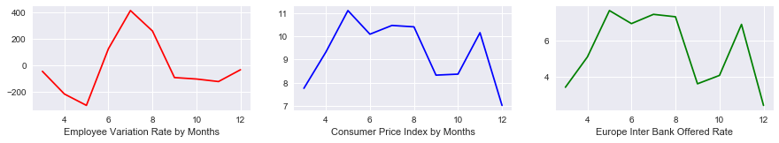

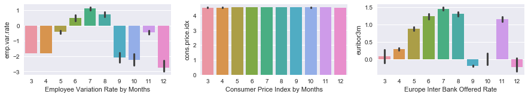

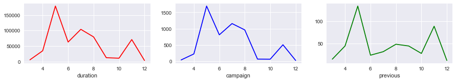

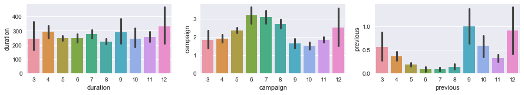

```python
plt.figure(figsize=(15,10))
f.set_figheight(10)
f.set_figwidth(25)

plt.subplot(4,3,1)
plt.plot(by_month['emp.var.rate'],'r-')
plt.xlabel('Employee Variation Rate by Months')
plt.subplot(4,3,2)
plt.plot(np.log(by_month['cons.price.idx']),'b-')
plt.xlabel('Consumer Price Index by Months')
plt.subplot(4,3,3)
plt.plot(np.log(by_month['euribor3m']),'g-')
plt.xlabel('Europe Inter Bank Offered Rate')

plt.figure(figsize=(15,10))
f.set_figheight(10)
f.set_figwidth(25)

plt.margins(0.1)
plt.subplot(4,3,4)
sns.barplot(y=data['emp.var.rate'],x=data['month'])
plt.xlabel('Employee Variation Rate by Months')
plt.subplot(4,3,5)
sns.barplot(y=np.log(data['cons.price.idx']),x=data['month'])
plt.xlabel('Consumer Price Index by Months')
plt.subplot(4,3,6)
sns.barplot(y=np.log(data['euribor3m']),x=data['month'])
plt.xlabel('Europe Inter Bank Offered Rate')

plt.figure(figsize=(15,10))
f.set_figheight(10)
f.set_figwidth(25)

plt.subplot(4,3,7)
plt.plot(by_month['duration'],'r-')
plt.xlabel('duration')
plt.subplot(4,3,8)
plt.plot(by_month['campaign'],'b-')
plt.xlabel('campaign')
plt.subplot(4,3,9)
plt.plot(by_month['previous'],'g-')
plt.xlabel('previous')

plt.figure(figsize=(15,10))
f.set_figheight(10)
f.set_figwidth(25)

plt.margins(0.1)
plt.subplot(4,3,10)
sns.barplot(y=data['duration'],x=data['month'])
plt.xlabel('duration')
plt.subplot(4,3,11)
sns.barplot(y=data['campaign'],x=data['month'])
plt.xlabel('campaign')
plt.subplot(4,3,12)
sns.barplot(y=data['previous'],x=data['month'])
plt.xlabel('previous')
```

**Weekday's Trends of Continuous Variables**

```python
dow  = {'mon':1,'tue':2,'wed':3,'thu':4,'fri':5}
data['day_of_week'] = data['day_of_week'].map(dow)
```

```python
by_dow = data.groupby('day_of_week').sum()
```

```
Text(0.5,0,'previous')
```

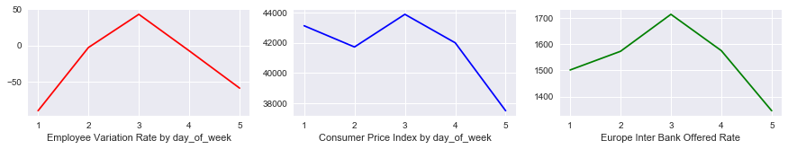

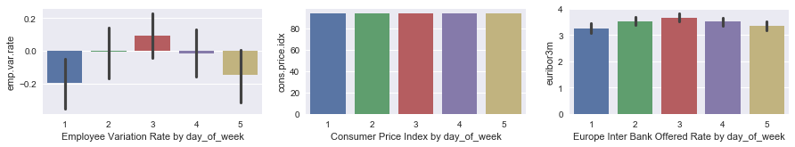

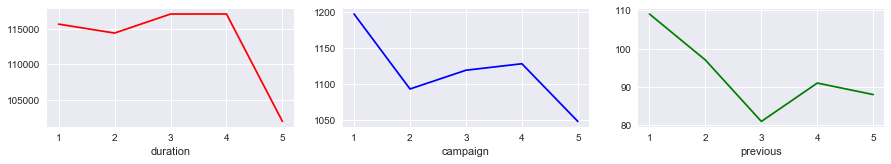

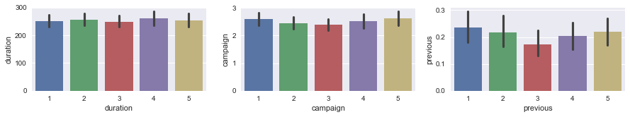

```python
plt.figure(figsize=(15,10))
f.set_figheight(10)
f.set_figwidth(25)

plt.subplot(4,3,1)
plt.plot(by_dow['emp.var.rate'],'r-')
plt.xlabel('Employee Variation Rate by day_of_week')
plt.subplot(4,3,2)
plt.plot(by_dow['cons.price.idx'],'b-')
plt.xlabel('Consumer Price Index by day_of_week')
plt.subplot(4,3,3)
plt.plot(by_dow['euribor3m'],'g-')
plt.xlabel('Europe Inter Bank Offered Rate')

plt.figure(figsize=(15,10))
f.set_figheight(10)
f.set_figwidth(25)

plt.margins(0.1)
plt.subplot(4,3,4)
sns.barplot(y=data['emp.var.rate'],x=data['day_of_week'])
plt.xlabel('Employee Variation Rate by day_of_week')
plt.subplot(4,3,5)
sns.barplot(y=data['cons.price.idx'],x=data['day_of_week'])
plt.xlabel('Consumer Price Index by day_of_week')
plt.subplot(4,3,6)
sns.barplot(y=data['euribor3m'],x=data['day_of_week'])
plt.xlabel('Europe Inter Bank Offered Rate by day_of_week')

plt.figure(figsize=(15,10))
f.set_figheight(10)
f.set_figwidth(25)

plt.subplot(4,3,7)
plt.plot(by_dow['duration'],'r-')
plt.xlabel('duration')
plt.subplot(4,3,8)
plt.plot(by_dow['campaign'],'b-')
plt.xlabel('campaign')
plt.subplot(4,3,9)
plt.plot(by_dow['previous'],'g-')
plt.xlabel('previous')

plt.figure(figsize=(15,10))
f.set_figheight(10)
f.set_figwidth(25)

plt.margins(0.1)
plt.subplot(4,3,10)
sns.barplot(y=data['duration'],x=data['day_of_week'])
plt.xlabel('duration')
plt.subplot(4,3,11)
sns.barplot(y=data['campaign'],x=data['day_of_week'])
plt.xlabel('campaign')
plt.subplot(4,3,12)
sns.barplot(y=data['previous'],x=data['day_of_week'])
plt.xlabel('previous')
```